# Homework 3 Solutions

### Definitions

Define the following terms/concepts

- a.) Sampling Error - how close a given estimate is from the true population parameter it is estimating
- b.) Law of Large Numbers - A theorem in probability and statistics which states that the relative frequency of an event will tend to “approach” (in some sense) the probability of an event as the number of observations increases
- c.) Sample Space - the collection of all possible outcomes of a random phenomena or experiment
- d.) Event - An outcome of a random phenomena or experiment
- e.) Union - the combined outcomes of two events
- f.) Intersection - the overlapping outcomes of two events
- g.) Random Trial - a process or experiment that can be repeated with a well-defined set of possible outcomes.
- h.) Random Variable - a function that maps from the sample space of event to a value
- i.) Probability distribution - a function that gives the probabilities of different possible outcomes of a random variable
- j.) Population distribution - is the probability distribution for a single observation of a random variable
- k.) Continuous random variable - A random variable with an uncountable number of outcomes
- l.) Discrete random variable - A random variable with a countable number of outcomes
- m.) Probability Mass Function - A function which assigns a probability to each outcome of a discrete random variable
- n.) Probability Density Function - A function which assigns probability density to different outcomes of a continuous random variable

## Simple probability

$\bf (1)$ A fair coin is thrown 3 times. What is the probability that at least one heads is observed?

$\bf (2)$ Suppose that in a class of 30 students, 8 students are in band, 15 students play a sport, and 5 students are both in band and play a sport. Let $A$ be the event that a student is in band and let $B$ be the event that a student plays a sport. Create a Venn diagram that models this situation. What is the probability that a student is in the band or plays a sport?

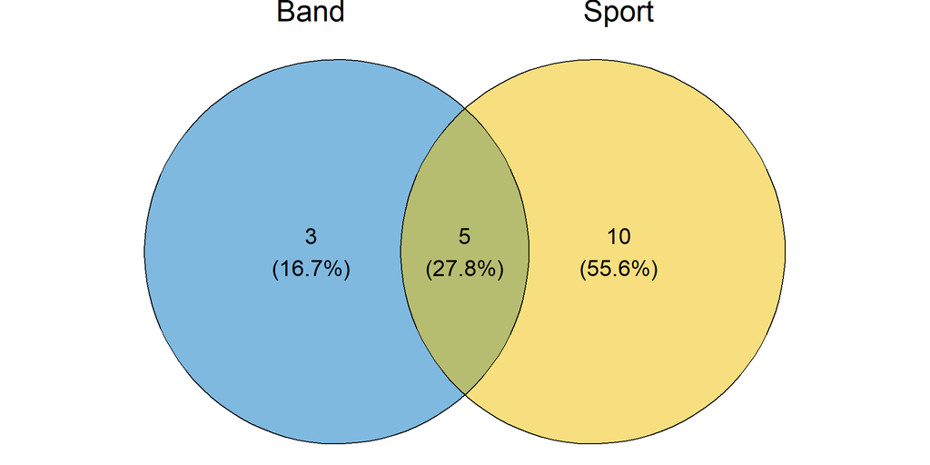

Since these events are non-disjoint, we must use the formula for a union of two non-disjoint events:
$$P(A\cup B) = P(A) + P(B) - P(A\cap B)$$
$$= \frac{8}{30}+\frac{15}{30} - \frac{5}{30}
=\frac{18}{30}$$

$\bf (3)$ A standard deck of 52 cards contains four suits (Hearts, Diamonds, Clubs, and Spades). Each suit contains 13 cards (9 numbered cards and 3 face cards, and an Ace).

- Suppose a single card is drawn at random, what is the probability that it is a numbered?

$$P(\text{Card
is numbered}) = \frac{\text{Number of ways to get numbered
card}}{\text{Total number of cards}} = \frac{9 \cdot 4}{52}$$

- What is the probability that the selected card is the Ace of Spades (assume independence where necessary)?

Let $A$ be the event that a card drawn at random is an Ace and $B$ be the event that a card drawn at random is a Spades. We are interested in the $P(A\cap B)$ and we are told to assume independence. Therefore
$$P(A\cap B) =
P(A)\cdot P(B) = \frac{4}{52} \cdot \frac{13}{52} =
\frac{1}{52}$$

$\bf (4)$ An urn contains 5 green balls, 7 red balls, and 4 yellow balls. Two balls are selected at random with replacement. What is the probability that first ball is yellow and the second ball is red?

Since the balls are selected with replacement the two events are independent. Therefore, the intersection of the two events: $A$ first ball yellow and $B$ second ball is red is given by
$$P(A\cap B) =
\frac{4}{16} \cdot \frac{7}{16} = \frac{7}{64}$$

$\bf (5)$ The probability that it rains $R$ on a given day in Moscow, Idaho is $P(R) = 0.1$. The probability that it is Windy $W$ is $P(W) = 0.2$, and the probability that it is cloudy $C$ is $P(C) = 0.7$. Assume that these three types of weather events are independent. What is the probability that a given day is both Rainy, Cloudy, and Windy?

We are told the events are independent and we wish to find the intersection of $R$, $W$ and $C$:
$$P(R\cap W\cap C) = (0.1)(0.2)(0.7) = 0.014$$

## Sampling Distributions, Means, and Variances

$\bf (6)$ A random variable $X$ has the following probability distribution

| X | P(X) |
| --- | --- |
| 1 | 0.25 |
| 2 | 0.25 |
| 3 | 0.25 |
| 4 | 0.25 |

- Derive the sampling distribution for the mean of $n=2$ observations of $\bar{X}$

The sample space for a mean of two observations of $X$ is given below.

| Observation 1 | Observation 2 | $\bar{X}$ |
| --- | --- | --- |
| 1 | 1 | 1.0 |
| 2 | 1 | 1.5 |
| 3 | 1 | 2.0 |
| 4 | 1 | 2.5 |
| 1 | 2 | 1.5 |
| 2 | 2 | 2.0 |
| 3 | 2 | 2.5 |
| 4 | 2 | 3.0 |
| 1 | 3 | 2.0 |
| 2 | 3 | 2.5 |
| 3 | 3 | 3.0 |
| 4 | 3 | 3.5 |
| 1 | 4 | 2.5 |
| 2 | 4 | 3.0 |
| 3 | 4 | 3.5 |
| 4 | 4 | 4.0 |

The sampling distribution of $\bar{X}$ is given by:

| $\bar{X}$ | $P(\bar{X})$ |
| --- | --- |
| 1.0 | $\color{red}{1(0.25^2)=0.0625}$ |
| 1.5 | $\color{red}{2(0.25^2)=0.125}$ |
| 2.0 | $\color{red}{3(0.25^2)=0.1875}$ |
| 2.5 | $\color{red}{4(0.25^2)=0.25}$ |
| 3.0 | $\color{red}{3(0.25^2)=0.1875}$ |
| 3.5 | $\color{red}{2(0.25^2)=0.125}$ |
| 4.0 | $\color{red}{1(0.25^2)=0.0625}$ |

- Compute the population mean $\mu$ and population standard deviation $\sigma$ of $X$

$$\mu =\sum_x
xP(x)$$
$$= 1(0.0625)+2(0.125)+\cdots
+3.5(0.125)+4(0.0625)$$
$$= 2.5$$

$\bf (7)$ A random variable $Y$ has two possible outcomes. The outcome $Y = 1$ occurs with probability $p = 0.23$. Derive the sampling distribution for the proportion of outcomes with $Y = 1$ in a sample of $n = 3$ observations of $Y$.

The population distribution of $Y$ is given by:

| $Y$ | $P(Y)$ |
| --- | --- |
| 0 | 0.77 |
| 1 | 0.23 |

The sample space for the sample proportion of 3 observations of $Y$ is given below.

| Observation 1 | Observation 2 | Observation 3 | $\hat{p}$ |
| --- | --- | --- | --- |
| 0 | 0 | 0 | 0.00 |
| 1 | 0 | 0 | 0.33 |
| 0 | 1 | 0 | 0.33 |
| 1 | 1 | 0 | 0.67 |
| 0 | 0 | 1 | 0.33 |
| 1 | 0 | 1 | 0.67 |
| 0 | 1 | 1 | 0.67 |
| 1 | 1 | 1 | 1.00 |

The sampling distribution of $\hat{p}$ is given by:

| $\hat{p}$ | $P(\hat{p})$ |
| --- | --- |
| 0.00 | $\color{red}{1(0.77^3)=0.457}$ |
| 0.33 | $\color{red}{3(0.23 \times 0.77^2)=0.409}$ |
| 0.67 | $\color{red}{3(0.23^2\times 0.77)=0.122}$ |
| 1.00 | $\color{red}{1(0.23^3)=0.012}$ |

$\bf (8)$ Consider a survey of tree volume. Suppose that in the population of trees $10\%$ have a volume of 10 cubic feet, $20\%$ have a volume of 20 cubic feet, $30\%$ have a volume of 30 cubic feet, and $40\%$ have a volume of 40 cubic feet. Let $X$ denote the volume of a randomly selected tree, assuming that every tree has an equal chance of being selected. The probability distribution of $X$ is given in the table below.

| X | P(X) |
| --- | --- |
| 10 | 0.1 |
| 20 | 0.2 |
| 30 | 0.3 |
| 40 | 0.4 |

- Confirm that $X$ has a mean of $\mu = 30$ cubic feet and a standard deviation of $\sigma = 10$ cubic feet by computing them yourself.

$$\mu = \sum_x
xP(x)$$
$$=
10(0.1)+20(0.2)+30(0.3)+40(0.4)$$
$$=
30$$

$$\sigma =
\sqrt{\sum_x (x-\mu)^2P(x)}$$
$$=
\sqrt{(10-30)^2(0.1)+(20-30)^2(0.2)+(30-30)^2(0.3)+(40-30)^2(0.4)}$$
$$= \sqrt{100}$$
$$= 10$$

- Derive the sampling distribution for the mean tree volume in a sample of $n = 2$ trees.

The sample space for the sample mean of 2 observations of tree volume is given below.

| Observation 1 | Observation 2 | $\bar{X}$ |
| --- | --- | --- |
| 10 | 10 | 10 |
| 20 | 10 | 15 |
| 30 | 10 | 20 |
| 40 | 10 | 25 |
| 10 | 20 | 15 |
| 20 | 20 | 20 |
| 30 | 20 | 25 |
| 40 | 20 | 30 |
| 10 | 30 | 20 |
| 20 | 30 | 25 |
| 30 | 30 | 30 |
| 40 | 30 | 35 |
| 10 | 40 | 25 |
| 20 | 40 | 30 |
| 30 | 40 | 35 |
| 40 | 40 | 40 |

The sampling distribution of $\bar{X}$ is given by:

| $\bar{X}$ | $P(\bar{X})$ |
| --- | --- |
| 10 | $\color{red}{(0.1)^2=0.01}$ |
| 15 | $\color{red}{2(0.1 \times 0.2)=0.04}$ |
| 20 | $\color{red}{2(0.1\times 0.3)+0.2^2=0.1}$ |
| 25 | $\color{red}{2(0.4\times 0.1)+2(0.2\times 0.3)=0.2}$ |
| 30 | $\color{red}{2(0.2\times 0.4)+0.3^2=0.25}$ |
| 35 | $\color{red}{2(0.3\times 0.4)=0.24}$ |
| 40 | $\color{red}{(0.4)^2=0.16}$ |

## Deriving Probabilities From Discrete Distributions

$\bf (9)$ Michael Dickson, who plays for the Seattle Seahawks, is a punter in the NFL. The following sampling distribution gives the mean punting distance (in yards) for a sample of $n=4$ punts. Use this distribution to answer the following questions:

| $\bar{X} =$ Mean Punt Distance | $P(\bar{X})$ |
| --- | --- |
| 35.33 | 0.40 |
| 45.67 | 0.50 |
| 55.00 | 0.08 |
| 60.33 | 0.01 |
| 65.67 | 0.01 |

- What is the probability the mean distance is 55 or more yards?

$$P(\bar{X}
\geq 55) = 1- P(\bar{X} < 55)$$
$$= 1-(0.4+0.5) = 0.1$$

- What is the probability the mean distance is at least 35.33 yards?

$$P(\bar{X}
\geq 35.33) = 1$$

- What is the probability the mean distance is between 35.33 and 45.67 yards?

$$P(35.33\leq
\bar{X} \leq 45.67) = P(X = 35.33)+P(X = 45.67) = 0.9$$

$\bf (10)$ A random variable $X$ follows a binomial distribution with with probability of success $p = 0.43$ and number of trials $n = 8$. What is the probability of observing fewer than 3 successes, that is what is $P(X < 3)$?

Let $X \sim Binomial(p = 0.43, n = 8)$ then

$$\color{red}{P(X < 3) = P(X = 0)+P(X
= 1)+P(X = 2)}$$

$$\color{red}{= \sum_{k = 0}^2
\frac{8!}{k!(8 - k)!} \times 0.43^{k} \times (1-0.43)^{8-k} \approx
0.256}$$

$\bf (11)$ Tom Brady is a famous quarterback who recently retired from playing in the National Football League. During his career, the probability that Brady would complete a pass in a given play was $64.3\%$. If a typical NFL team runs about $35$ offensive pass plays, what is the probability that Brady would complete exactly $28$ pass plays in a game?

Let $X \sim Binomial(p = 0.643, n = 35)$ then

$$\color{red}{P(X = 28) =
\frac{35!}{28!(35 - 28)!} \times 0.643^{28}\times (1-0.643)^{35-28}
\approx 0.021}$$

$\bf (12)$ A random variable $W$ follows a Poisson distribution with rate parameter $\lambda = 1.8$ events per hour. What is the probability of observing exactly four events in a given hour, that is what is $P(W = 4)$?

Let $W\sim Poisson(\lambda = 1.8)$
$$P(W = 4) =
\frac{1.8^4\cdot e^{-1.8}}{4!} \approx 0.072$$

$\bf (13)$ A factory experiences on average 3 equipment malfunctions per day, following a Poisson distribution with a rate parameter of 3. Calculate the probability that on a randomly selected day, the factory will observe 3 or more equipment malfunctions.

let $X$ represent the number of equipment failures in a given day for the factor, then
$$X\sim Poisson(\lambda =
3)$$
$$P(X\geq 3) = 1 - P(X<
3)$$
$$P(X < 3) = P(X = 0)+P(X =
1)+P(X = 2)$$
$$= 1-\sum_{k=0}^2
\frac{3^k\cdot e^{-3}}{k!} \approx 0.577$$

## Deriving Probabilities From Continuous Distributions

${\bf (14)}$ Use the plot below of the probability distribution of a continuous random variable $X$ to answer the following questions

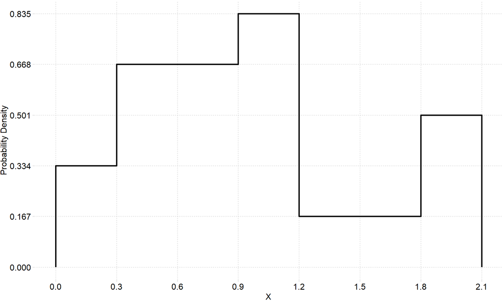

Use the plot to find the following probabilities:

- What is $P(X<0.6)$?

In this plot the area comprising a single grid square is
$$\text{Area of a rectangle}
= \text{Base}\times\text{Height} = 0.167\times 0.3 \approx 0.05$$
there are six grid squares between $0$ and $0.6$, therefore
$$P(X<0.6)= 6\times 0.05 =
0.3$$

- What is $P(X>0.3)$?

$P(X>0.3)= 1-P(X\leq 0.3) = 1-(2*0.05) = 0.9$

- What is $P(1.5<X<1.8)$?

$P(1.5<X<1.8)=0.05$

${\bf (15)}$ Use the plot below of the probability distribution of a continuous random variable $Y$ to answer the following questions

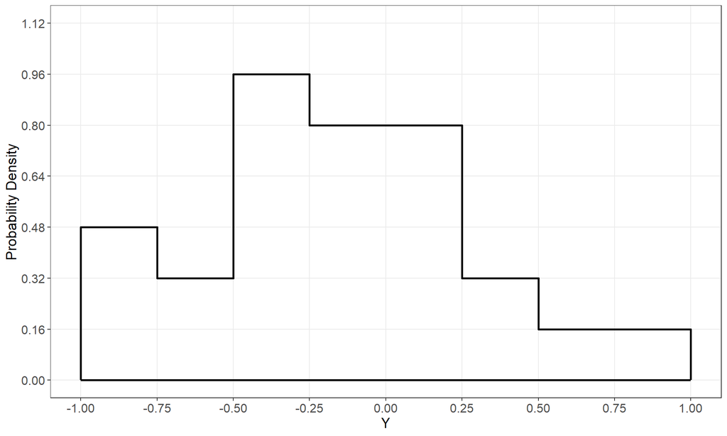

Use the plot to find the following probabilities (recall that the area of a triangle is $\frac{1}{2} \times \text{base} \times \text{height}$)

- What is $P(Y>-0.25)$?

In this plot the area comprising a single grid square is
$$\text{Area of a rectangle}
= \text{Base}\times\text{Height} = 0.25\times 0.16 \approx 0.04$$
There are $14$ grid squares in the area between $-0.25$ and $1.0$ $P(Y>-0.25)=14\times 0.04 = 0.56$

- What is $P(-0.5<Y<0.25)$?

There are $16$ grid squares in the area between $-0.5$ and $0.25$ therefore $P(-0.5<Y<0.25)=16\times 0.04 = 0.64$

${\bf (16)}$ Use the plot below of the probability distribution of a continuous random variable $Z$ to answer the following questions

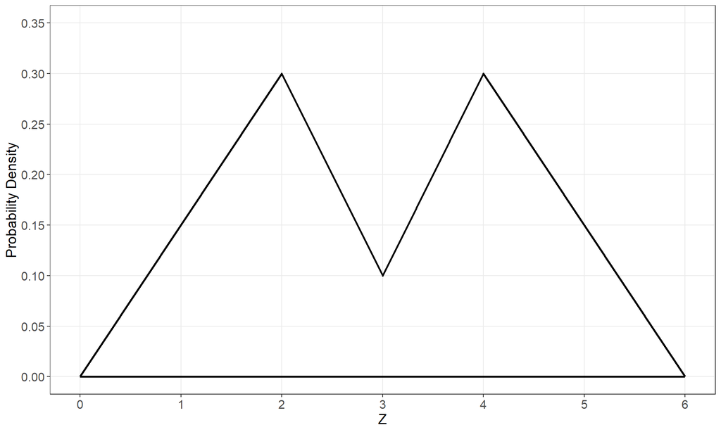

Use the plot to find the following probabilities (recall that the area of a triangle is $\frac{1}{2} \times \text{base} \times \text{height}$)

- What is $P(Z<2)$?

$P(Z<2)=0.5(2)(0.3) = 0.3$

- What is $P(2<Z<3)$?

In this plot a single grid square has an area of $0.05$ thus the area between $Z = 2$ and $Z = 3$ is given by $P(2<Z<3)=2(0.05)+(0.5)(1)(0.2) = 0.2$

- What is $P(Z>4)$?

$P(Z>4) = P(Z<2) =0.3$

- Give the approximate value of the $25th$ percentile of distribution of $Z$

$Q1 \approx 2$

${\bf 17.)}$ Assume the continuous random variable $X$ follows a normal distribution with mean $\mu = 25$ and variance $\sigma^2 = 16$.

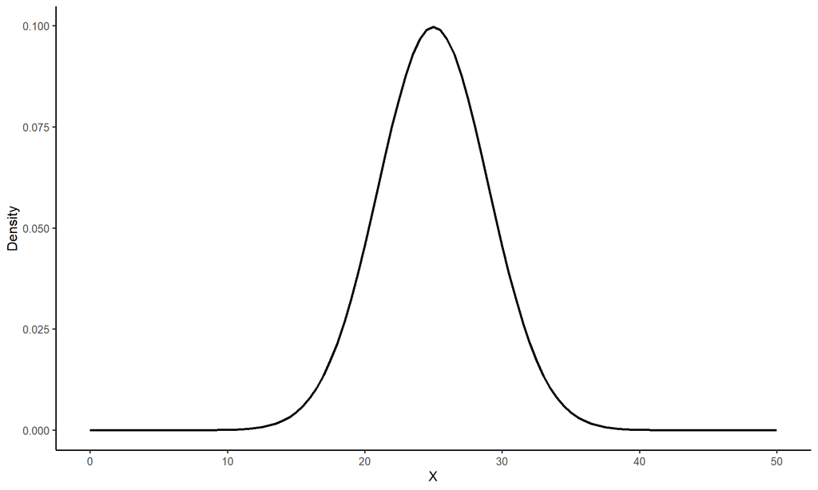

Using a $Z$-table, find the following (approximate) probabilities for $X$. You can also use the app in the course website or [StatDistributions.com](http://www.statdistributions.com/normal/) to check your result

- What is $P(X<15)$?

$$z =
\frac{15-25}{4} = -2.5$$
$$P(Z<-2.5) = 0.006$$

- What is $P(X>28)$?

$$z =
\frac{28-25}{4} = 0.75$$
$$P(Z>0.75) = 1-P(Z\leq 0.75) = 1-0.773 = 0.227$$

- What is $P(12<X<20)$?

$$z_{\text{lower}} = \frac{12-25}{4} = -3.25$$
$$z_{\text{upper}} = \frac{20-25}{4} =
-1.25$$
$$P(-3.25 < Z < -1.25)
= P(Z<-1.25) - P(Z<-3.25) = 0.106 - 0.001 =
0.105$$

- What is $P(X>30)$?

$$z =
\frac{30-25}{4} = 1.25$$
$$P(Z>1.25) = 1-P(Z\leq 1.25) = 1-0.894 = 0.106$$

- What is $P(25<X<33)$?

$$z_{\text{lower}} = \frac{25-25}{4} = 0$$
$$z_{\text{upper}} = \frac{33-25}{4} = 2$$
$$P(0<Z<2) = P(Z<2) - P(Z<0) =
0.977 - 0.5 = 0.477$$

- What is the value of $X$ marks the $95th$ percentile of the distribution?

the $95th$ percentile of a standard normal distribution is $z=1.645$ plugging this into the $z$-score equation and solving for $X$ gives
$$(z\times \sigma) + \mu = (1.645\times 4) + 25 =
31.58$$

- What is the value of $X$ marks the $40th$ percentile of the distribution?

the $40th$ percentile of a standard normal distribution is $z=-0.253$
$$(z\times \sigma) + \mu = (-0.253\times 4)+25 =
23.9$$

${\bf 18.)}$ Suppose that a random variable $X$ follows a normal distribution with mean $\mu = -5$ and standard deviation $\sigma = 1.8$. Using the plot of a the $Z$-distribution below, shade in the area corresponding to the probability $P(-2< X <0.5)$

start by finding the $z$-scores
$$P(-2<X<0.5) = P(X<0.5) - P(X<-2)$$
$$z_{\text{lower}} = \frac{0.5 - (-5)}{1.8} =
3.06$$
$$z_{\text{upper}} = \frac{-2
- (-5)}{1.8} = 1.67$$
$$P(-2<X<0.5) = P(1.67< Z <
3.06)$$

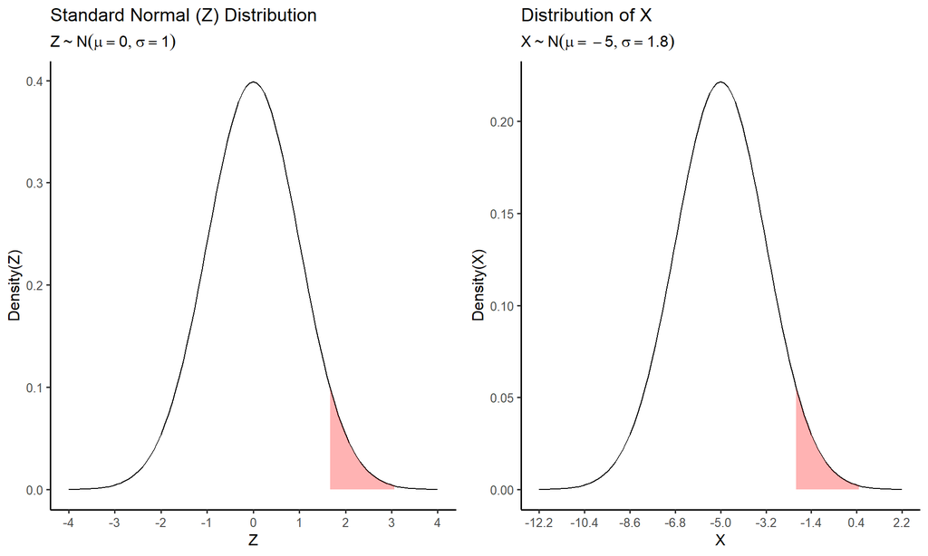